[OHI British Columbia](http://www.ohibc.org/) | [OHI Science](http://ohi-science.org) | [Citation policy](https://github.com/OHI-Science/ohiprep/releases)

# OHIBC: Ultraviolet Anomalies Pressure layers prep

Compiled on Thu Mar 17 16:45:56 2016 by ohara

# 1 Summary

There are two parts to creating this layer:

1. Data prep to get raw data into the correct format:
   - Read anomalies data as raster for 1997-2001 and 2010-2014.
   - Clip rasters to extents of OHIBC region, and reproject into BC Albers projection.
2. Creating the pressure layers for OHIBC:
   - Determine change in anomalies since baseline.
   - Set negative values to zero (only interested in increases).
   - Resample to 1 km.
   - Log transform results.
   - Interpolate to coastline at 1 km resolution.
   - Rescale zero to 1, where 1 is 99.99%ile

This process is completed entirely within this script.

# 2 Updates

Not applicable.

# 3 Data

The Ultraviolet Radiation pressures layer uses the Aura OMI GLobal Surface UVB Data Product.

- Native Data Resolution: 1 degree
- Values: Level-3 OMI Surface UV Irradiance and Erythemal Dose- OMUVBd
- Time Range: Daily data from 2004 - 2014
- Format: HDF5

# 4 Methods

## 4.1 Data Prep

### 4.1.1 Read raw data

Raw data is read in for 1997-2001 and 2010-2014 datasets.

Range of UV<sub>1997-2001</sub> for global dataset: 1 - 19.

Range of UV<sub>2010-2014</sub> for global dataset: 2 - 20.

### 4.1.2 Convert raw global data to OHIBC region data

The raw data, in WGS84 coordinate ref system, is rasterized, clipped down to a bounding box around the OHIBC region, and reprojected into BC Albers projection. This data is then resampled to 1 km resolution using nearest neighbor method.

The resulting raster layers include total UV anomalies for each coarse cell (approx 1 degree, from original resolution) the two time periods.

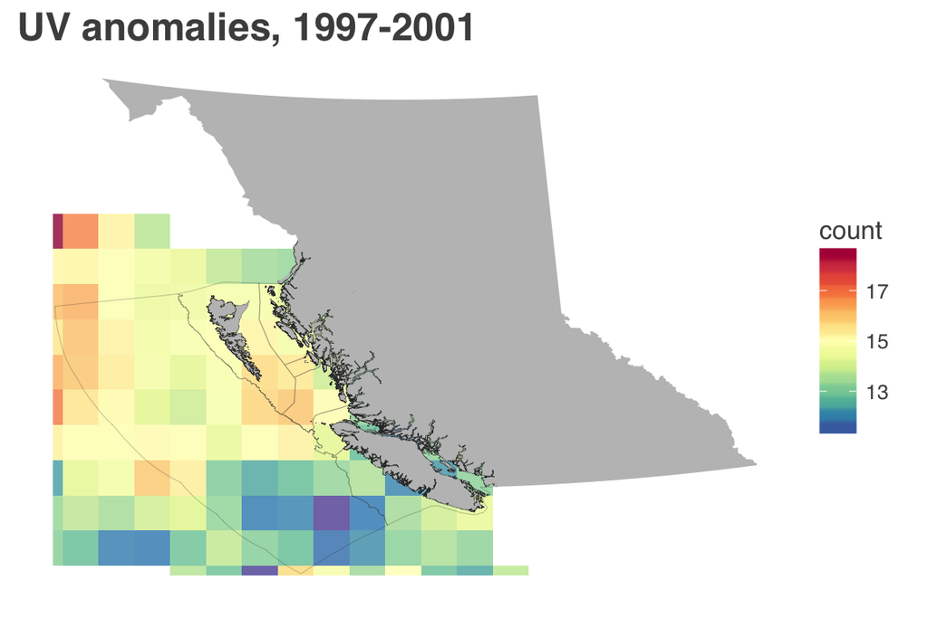

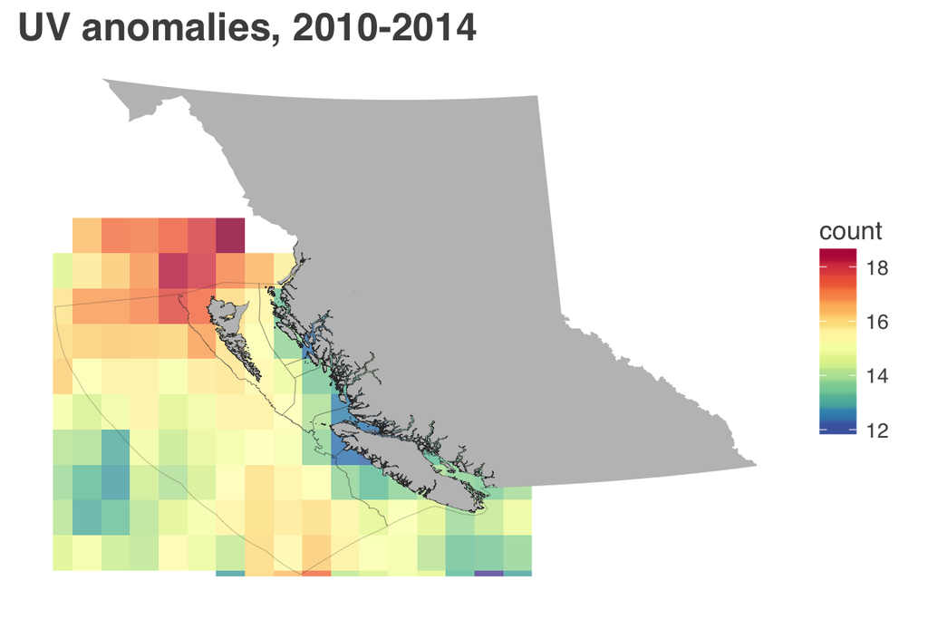

## 4.2 Rescale values as pressures

Baseline UV anomaly frequency is based upon the count within 1997 to 2001.

Change in UV anomaly frequency is determined by simple subtraction of the 1997-2001 raster from the 2010-2014 raster. Because the raw rasters seem to be on different grids, differences at native resolution cell edges are very uneven; so we interpolate each layer using thin plate spline before subtracting.

Values below zero (drop in UV anomaly frequency) are set to zero.

This difference value is log+1 transformed, then rescaled from zero (no change in anomalies) to 1 (at 99.99%ile of anomalies).

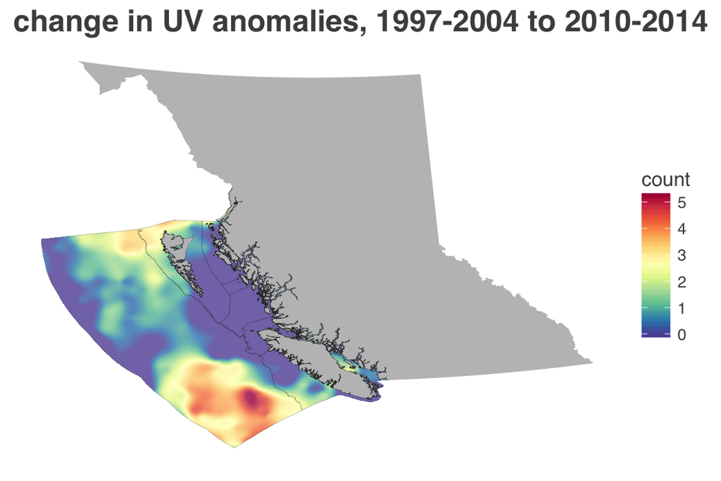

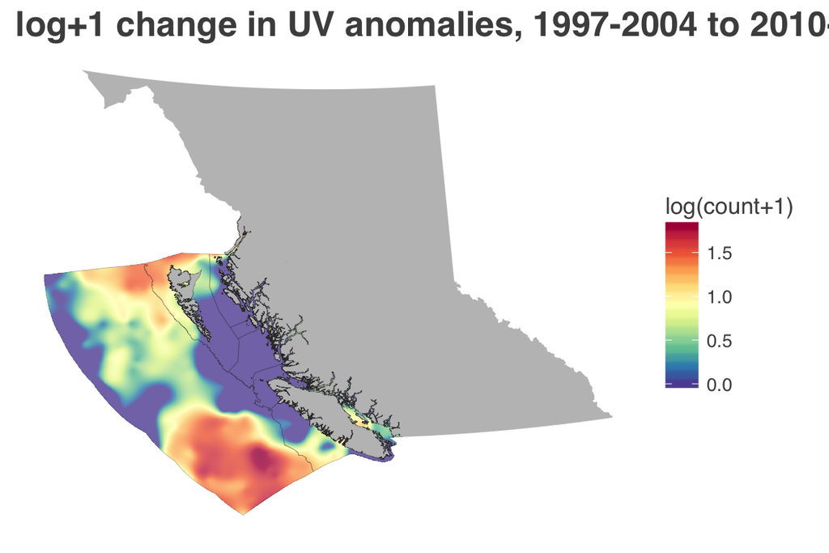

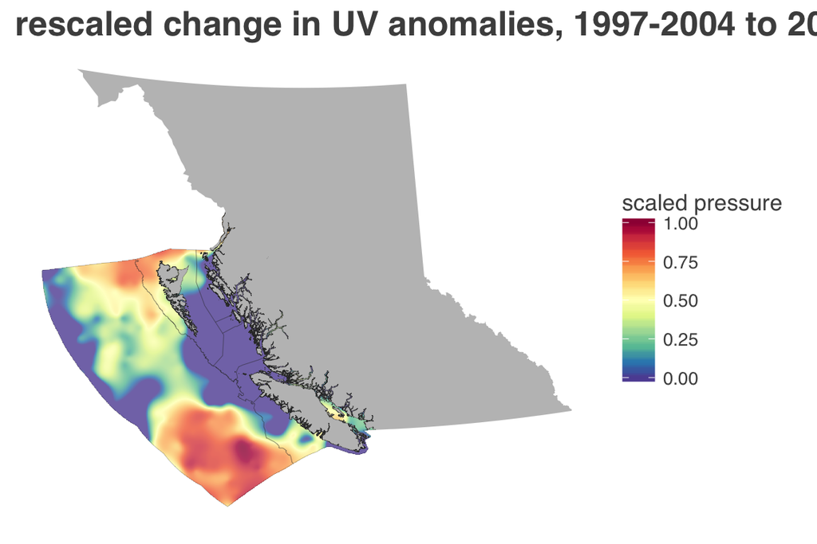

## 4.3 Calculate mean pressure by region by year

Using 1000 m region ID raster to run zonal statistics on the pressures layers, calculate the regional average pressures for the study period, and save as a .csv.

| rgn_id | pressure | rgn_name |
| --- | --- | --- |
| 1 | 0.0826168 | North Coast |
| 2 | 0.3028928 | Haida Gwaii |
| 3 | 0.0146718 | Central Coast |
| 4 | 0.0558820 | North Vancouver Island |
| 5 | 0.2231086 | West Vancouver Island |
| 6 | 0.2363911 | Strait of Georgia |
| 7 | 0.4144101 | Pacific Offshore |
| 8 | 0.0000000 | Aristazabal Island |

# 5 Provenance

- *Run ID: 3; run tag: “standard run”*
- *Run elapsed time: 298.632 seconds; run memory usage: NA MB*
- *System info: System: Darwin, Release: 15.3.0. Machine: x86_64. User: ohara.*
- *Session info*
  - *R version: R version 3.2.2 (2015-08-14), Platform: x86_64-apple-darwin13.4.0, Running under: OS X 10.11.3 (El Capitan).*
  - *Attached base packages: stats, graphics, grDevices, utils, datasets, methods, base*
  - *Other attached packages: maptools_0.8-39, RColorBrewer_1.1-2, ggplot2_2.1.0, readr_0.2.2, stringr_1.0.0, tidyr_0.4.1, dplyr_0.4.3, raster_2.5-2, rgdal_1.0-4, sp_1.2-2*

Provenance summary for this run:

| run_id | run_tag | run_date | file_loc | type | commit_url | commit_author | commit_date | uncommitted_changes |
| --- | --- | --- | --- | --- | --- | --- | --- | --- |
| 3 | standard run | Thu Mar 17 16:50:58 2016 | ~/github/ohibc/prep/pressures/v2016/pressures_lyr_fxns.R | sourced_script | https://github.com/OHI-Science/ohibc/commit/5f6534a816eedf6fbe016bfeb156a5d4295fff85 | Casey O’Hara ohara@nceas.ucsb.edu | Tue Mar 15 11:09:01 2016 -0700 | FALSE |
| 3 | standard run | Thu Mar 17 16:50:58 2016 | ~/github/ohibc/src/R/rast_tools.R | sourced_script | https://github.com/OHI-Science/ohibc/commit/6fac3638d2a10f9836c6f059dfbadc3a5011b1bf | Casey O’Hara ohara@nceas.ucsb.edu | Wed Mar 16 15:34:30 2016 -0700 | FALSE |
| 3 | standard run | Thu Mar 17 16:50:58 2016 | /Volumes/data_edit/git-annex/globalprep/Pressures_UV/data/uv_omi_aura_2013_2014/uv_baseline_anomaly/omi_aura_uv_anomaly_2010m01-2014m12_raw.tif | input | no version control info found | NA | NA | TRUE |
| 3 | standard run | Thu Mar 17 16:50:58 2016 | /Volumes/data_edit/git-annex/globalprep/Pressures_UV/data/uv_omi_aura_2013_2014/uv_baseline_anomaly/toms_ep_uv_anomaly_1997m01-2001m12_raw.tif | input | no version control info found | NA | NA | TRUE |
| 3 | standard run | Thu Mar 17 16:50:58 2016 | /Users/ohara/github/ohibc/prep/regions/ohibc_rgn.shp | input | https://github.com/OHI-Science/ohibc/commit/b4848d164d7ab5393da401425b57d0a540866c1f | Casey O’Hara ohara@nceas.ucsb.edu | Wed Oct 28 15:07:36 2015 -0700 | FALSE |
| 3 | standard run | Thu Mar 17 16:50:58 2016 | /Users/ohara/github/ohibc/prep/regions/ohibc_rgn_wgs84.shp | input | https://github.com/OHI-Science/ohibc/commit/b014927db4445d63bc01ddf683252c301cd59d0f | Casey O’Hara ohara@nceas.ucsb.edu | Wed Oct 28 11:55:33 2015 -0700 | FALSE |
| 3 | standard run | Thu Mar 17 16:50:58 2016 | ~/github/ohibc/prep/regions/ohibc_rgn_raster_1000m.tif | input | https://github.com/OHI-Science/ohibc/commit/c4744464da326817b3f3c0f5634f5bfbd2f59e12 | Casey O’Hara ohara@nceas.ucsb.edu | Tue Mar 15 15:05:57 2016 -0700 | FALSE |
| 3 | standard run | Thu Mar 17 16:50:58 2016 | ~/github/ohibc/prep/pressures/v2016/int/uv/rast_uv_past_raw.tif | input | https://github.com/OHI-Science/ohibc/commit/6fac3638d2a10f9836c6f059dfbadc3a5011b1bf | Casey O’Hara ohara@nceas.ucsb.edu | Wed Mar 16 15:34:30 2016 -0700 | FALSE |
| 3 | standard run | Thu Mar 17 16:50:58 2016 | ~/github/ohibc/prep/pressures/v2016/int/uv/rast_uv_curr_raw.tif | input | https://github.com/OHI-Science/ohibc/commit/6fac3638d2a10f9836c6f059dfbadc3a5011b1bf | Casey O’Hara ohara@nceas.ucsb.edu | Wed Mar 16 15:34:30 2016 -0700 | FALSE |
| 3 | standard run | Thu Mar 17 16:50:58 2016 | ~/github/ohibc/prep/pressures/v2016/output/uv/uv_rescaled_2010-2014.tif.shp | output | no version control info found | NA | NA | TRUE |
| 3 | standard run | Thu Mar 17 16:50:58 2016 | ~/github/ohibc/prep/pressures/v2016/output/uv/uv_rgn_pressures.csv | output | New commit: https://github.com/OHI-Science/ohibc/commit/c9836eaa7447f6e1c607de19bed399960a24a359 | Casey O’Hara ohara@nceas.ucsb.edu | Thu Mar 17 16:50:57 2016 -0700 | FALSE |
| 3 | standard run | Thu Mar 17 16:50:58 2016 | ~/github/ohibc/prep/pressures/v2016/pressures_uv_prep.Rmd | script | https://github.com/OHI-Science/ohibc/commit/ec2b37a1f6364de9bc979f0a908bae55ec076222 | Casey O’Hara ohara@nceas.ucsb.edu | Thu Mar 17 16:13:56 2016 -0700 | TRUE |